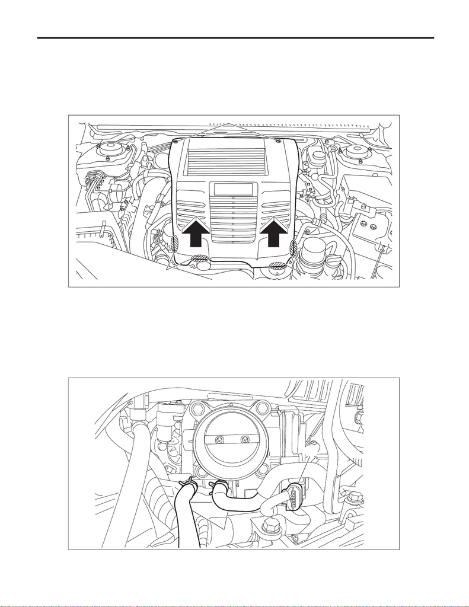

Throttle Body

2. Throttle Body

A: REMOVAL

1) Remove the collector cover.

(1) Remove the clips (A).

(2) Hold the shaded area (B) by hand and carefully pull the RH side (C) upward.

(3) Hold the shaded area (D) by hand and carefully pull the LH side (E) upward.

2) Disconnect the ground terminal from battery sensor. <Ref. to NT-5, BATTERY, NOTE, Note.>

3) Lift up the vehicle.

4) Remove the under cover. <Ref. to EI-21, REMOVAL, Front Under Cover.>

GINE COOLANT, REPLACEMENT, Engine Coolant.>

6) Remove the intercooler. <Ref. to IN(w/o STI)-38, REMOVAL, Intercooler.>

7) Remove the intake duct No. 3. <Ref. to IN(w/o STI)-28, INTAKE DUCT NO. 3, REMOVAL, Intake Duct.>

8) Disconnect the connector (A) from the throttle position sensor, and disconnect the preheater hose (B) from

the throttle body.

EX-03204

(A)

(B)

(C)

(E)

(D)

FU-08479

(B)

(A)

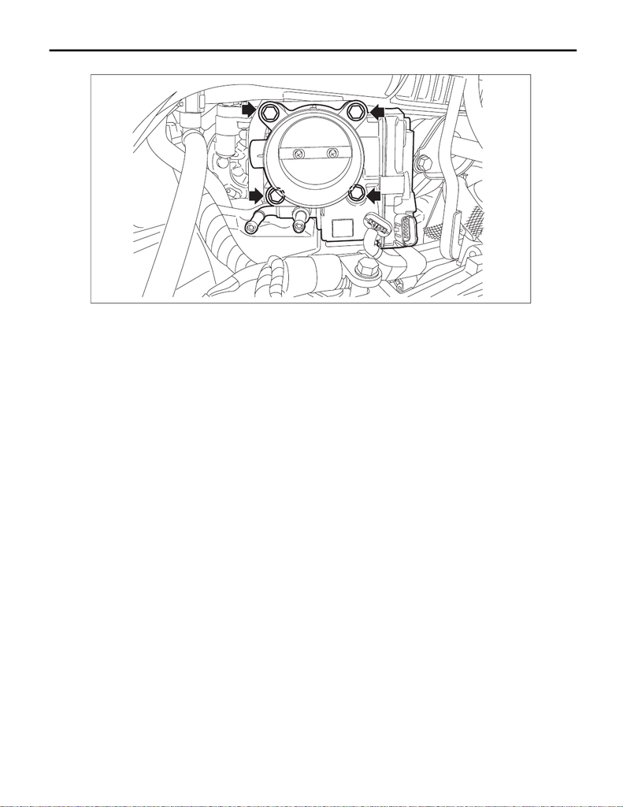

Throttle Body

9) Remove the throttle body from the intake manifold.

B: INSTALLATION

Install in the reverse order of removal.

NOTE:

Use a new gasket.

Tightening torque:

8 N·m (0.8 kgf-m, 5.9 ft-lb)

C: INSPECTION

1. THROTTLE SENSOR (METHOD WITH CIRCUIT TESTER)

1) Disconnect the ground terminal from battery sensor. <Ref. to NT-5, BATTERY, NOTE, Note.>

2) Remove the engine control module (ECM). <Ref. to FU(w/o STI)-132, REMOVAL, Engine Control Module

(ECM).>

ag)-6, CAUTION, General Description.>

ST 18460AA030 CHECK BOARD

4) Connect the ground terminal to battery sensor. <Ref. to NT-5, BATTERY, NOTE, Note.>

5) After warming-up the engine, turn the ignition switch to OFF.

6) Turn the ignition switch to ON. (engine OFF)

FU-08480

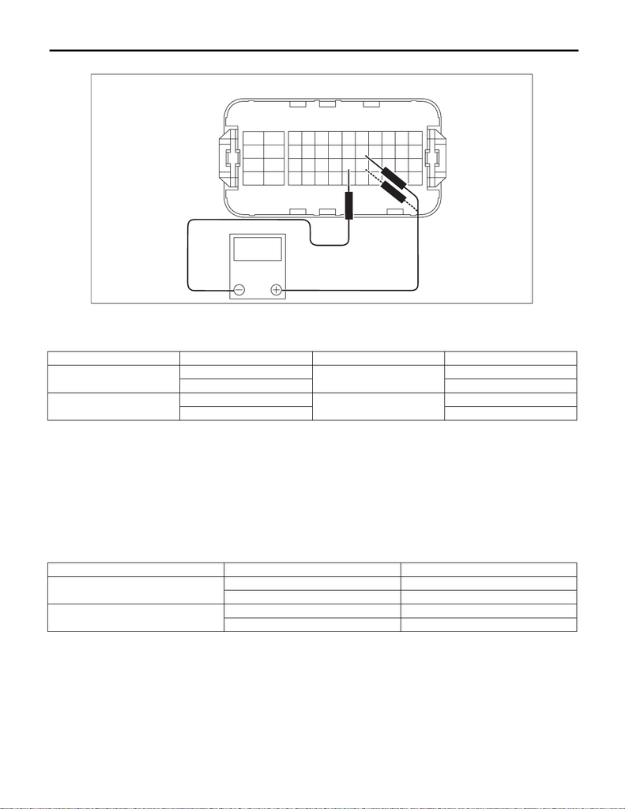

Throttle Body

7) Measure the voltage between ECM connector terminals using ST.

8) After inspection, install the related parts in the reverse order of removal.

2. THROTTLE SENSOR (METHOD WITH SUBARU SELECT MONITOR)

1) After warming-up the engine, turn the ignition switch to OFF.

2) Turn the ignition switch to ON. (engine OFF)

3) Read the throttle opening angle signal and voltage of throttle sensor using Subaru Select Monitor. <Ref.

to EN(w/o STI)(diag)-37, DISPLAY CURRENT ENGINE DATA, OPERATION, Subaru Select Monitor.>

NOTE:

Due to the specification of the Subaru Select Monitor, value read from the throttle opening angle signal is

highlighted and displayed as the voltage readings of sub throttle sensor.

3. OTHER INSPECTIONS

1) Check that the throttle body has no deformation, cracks or other damages.

2) Check that the preheater hose has no cracks, damage or loose part.

(A) To the check board connector

(ECM connector)

Throttle sensor Accelerator pedal Terminal No. Standard

Main

Not depressed (full closed)

17 (+) and 30 (–)

Approx. 0.7 V

Depressed (full opened) Approx. 3.9 V

Sub

Not depressed (full closed)

29 (+) and 30 (–)

Throttle sensor Throttle opening angle signal Standard

Main

0.0% Approx. 0.7 V

100.0% Approx. 3.9 V

Sub

0.0% Approx. 1.1 V

100.0% Approx. 4.4 V

FU-08453

V

(A)

7

9

10

8

5

23

1112

6

19

21

22

20

17

24

3536

4748

18

31

33

34

32

2930

43

45

46

44

4142

3

4

12

15

16

1314

27

28

2526

39

40

3738